# Case Study 1: Exploratory Data Analysis (EDA) for Budweiser

Phu Truong & Kristi Herman

01/20/2020

## Introduction

- The purpose of this exploratory data analysis is to answer questions from Budweiser related to the craft beer industry in the United States.

```r
# Import dependencies
library(tidyverse)
```

```r
library(dplyr)
library(ggplot2)
library(data.table)
library(ggthemes)
library(naniar)
library(class)
library(caret)
library(plotly)
library(GGally)
library(ggpubr)
library(tidycensus)
library(fiftystater) # Latitude and longitude for 50 states
data(fifty_states) # Import the data

# Import Beer and Brewery data
beer_df <-  read_csv("Beers.csv")
brew_df <-  read_csv("Breweries.csv")
cities_df <- read_csv("cities.csv", col_types = list(col_character(), col_double(), col_double()))

# Check to make sure data imported
dim(beer_df)
```

```
## [1] 2410    7
```

```r
dim(brew_df)
```

```
## [1] 558   4
```

```r
View(brew_df)
```

## 1. How many breweries are present in each state?

- Colorado has the most number of craft breweries.

```r
#  Group breweries by state
brew_by_state <- brew_df %>% group_by(State) %>% summarize(count=n())

# Display # of breweries by state
View(brew_by_state)
```

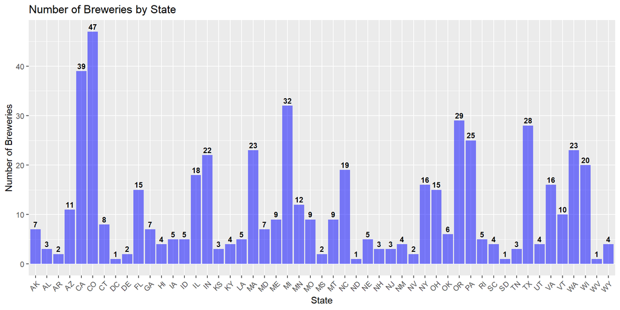

```r
# Plot # of breweries by state in a barchart
p <- brew_by_state %>%
  ggplot(aes(x = State, y = count)) +
  geom_bar(stat = "identity", fill = "blue", alpha = .5) +
  ggtitle("Number of Breweries by State") + xlab("State") + ylab("Number of Breweries") +
  geom_text(aes(y = count, label = count), fontface = "bold", vjust = -.4, color = "black", size = 3)

p + rotate_x_text(45)
```

```r
# In order to plot the count of breweries on the states using the fifty_states data, get the full state names and add them to the brew_by_state df

# Function to take a list of state abbreviations and return the full state names.  'x' is the column of the df that holds 2-letter state codes.
state_from_lower <- function(x) {
  # DF wth 52 state codes and state names [includes DC (Washington D.C. and PR (Puerto Rico)]
  st_codes <- data.frame(
                      st_abbr=as.factor(c("AK", "AL", "AR", "AZ", "CA", "CO", "CT", "DC", "DE", "FL", "GA",
                                         "HI", "IA", "ID", "IL", "IN", "KS", "KY", "LA", "MA", "MD", "ME",
                                         "MI", "MN", "MO", "MS",  "MT", "NC", "ND", "NE", "NH", "NJ", "NM",
                                         "NV", "NY", "OH", "OK", "OR", "PA", "PR", "RI", "SC", "SD", "TN",
                                         "TX", "UT", "VA", "VT", "WA", "WI", "WV", "WY")),
                      full=as.factor(c("alaska","alabama","arkansas","arizona","california","colorado",
                                       "connecticut","district of columbia","delaware","florida","georgia",
                                       "hawaii","iowa","idaho","illinois","indiana","kansas","kentucky",
                                       "louisiana","massachusetts","maryland","maine","michigan","minnesota",
                                       "missouri","mississippi","montana","north carolina","north dakota",
                                       "nebraska","new hampshire","new jersey","new mexico","nevada",
                                       "new york","ohio","oklahoma","oregon","pennsylvania","puerto rico",
                                       "rhode island","south carolina","south dakota","tennessee","texas",
                                       "utah","virginia","vermont","washington","wisconsin",
                                       "west virginia","wyoming"))
                       )

  # Create a df of state codes from x variable
  st_abbr_df <- data.frame(state=x)

  # Match state codes with codes from 'st_codes' df and use it to return the full state name
  ret_state <- st_codes$full[match(st_abbr_df$state,st_codes$st_abbr)]
  print(ret_state)

  # Return the full state names in the same order in which they appeared in the original source
  return(ret_state)
}

brew_by_state$id <- state_from_lower(brew_by_state$State)
```

```
##  [1] alaska               alabama              arkansas
##  [4] arizona              california           colorado
##  [7] connecticut          district of columbia delaware
## [10] florida              georgia              hawaii
## [13] iowa                 idaho                illinois
## [16] indiana              kansas               kentucky
## [19] louisiana            massachusetts        maryland
## [22] maine                michigan             minnesota
## [25] missouri             mississippi          montana
## [28] north carolina       north dakota         nebraska
## [31] new hampshire        new jersey           new mexico
## [34] nevada               new york             ohio
## [37] oklahoma             oregon               pennsylvania
## [40] rhode island         south carolina       south dakota
## [43] tennessee            texas                utah
## [46] virginia             vermont              washington
## [49] wisconsin            west virginia        wyoming
## 52 Levels: alabama alaska arizona arkansas california colorado ... wyoming
```

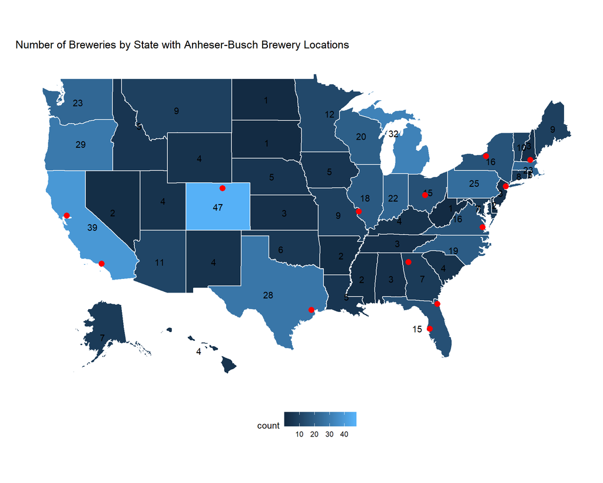

```r
# Plot the US map with the number of craft breweries as labels and points for Budweiser locations.  The fifty_states data
map_w_brew <- ggplot(data = brew_by_state, aes(map_id = id)) +
  geom_map(aes(fill = count),  color= "white", map = fifty_states) +
  expand_limits(x = fifty_states$long, y = fifty_states$lat) +
  coord_map() +
  ggtitle("Number of Breweries by State with Anheser-Busch Brewery Locations") +
  geom_text(data = fifty_states %>%
              group_by(id) %>%
              summarise(lat = mean(c(max(lat), min(lat))),
                        long = mean(c(max(long), min(long)))) %>%
              mutate(state = id) %>%
              left_join(brew_by_state, by = "id"), aes(x = long, y = lat, label = count))+
  scale_x_continuous(breaks = NULL) + scale_y_continuous(breaks = NULL) +
  labs(x = "", y = "") + theme(legend.position = "bottom",
                               panel.background = element_blank())
map_w_brew  + geom_point(data = cities_df, aes(longitude, latitude), size = 3, color = "red", inherit.aes=FALSE)
```

## 2. Merge the Beer Data with the Brewery Data. Print first and last six observations.

```r
# Change the column names in the Beer df
setnames(beer_df, old=c("Name","Brewery_id"), new=c("Beer_name", "Brew_ID"))

# Change column name in the Brewery df
setnames(brew_df, old=c("Name"), new=c("Brewery_name"))

# Make the state column a factor
brew_df$State <-  factor(brew_df$State)
str(brew_df)
```

```
## Classes 'spec_tbl_df', 'tbl_df', 'tbl' and 'data.frame': 558 obs. of  4 variables:
##  $ Brew_ID     : num  1 2 3 4 5 6 7 8 9 10 ...
##  $ Brewery_name: chr  "NorthGate Brewing" "Against the Grain Brewery" "Jack's Abby Craft Lagers" "Mike Hess Brewing Company" ...
##  $ City        : chr  "Minneapolis" "Louisville" "Framingham" "San Diego" ...
##  $ State       : Factor w/ 51 levels "AK","AL","AR",..: 24 18 20 5 5 41 6 23 23 23 ...
##  - attr(*, "spec")=
##   .. cols(
##   ..   Brew_ID = col_double(),
##   ..   Name = col_character(),
##   ..   City = col_character(),
##   ..   State = col_character()
##   .. )
```

```r
# Merge the brewery data with the beer data (left join)
all_df <- merge(beer_df, brew_df, by="Brew_ID")
dim(all_df)
```

```
## [1] 2410   10
```

```r
# Print the first & last 6 observations
(first6= head(all_df,6))
```

```
##   Brew_ID     Beer_name Beer_ID   ABV IBU                               Style
## 1       1  Get Together    2692 0.045  50                        American IPA
## 2       1 Maggie's Leap    2691 0.049  26                  Milk / Sweet Stout
## 3       1    Wall's End    2690 0.048  19                   English Brown Ale
## 4       1       Pumpion    2689 0.060  38                         Pumpkin Ale
## 5       1    Stronghold    2688 0.060  25                     American Porter
## 6       1   Parapet ESB    2687 0.056  47 Extra Special / Strong Bitter (ESB)
##   Ounces      Brewery_name        City State
## 1     16 NorthGate Brewing Minneapolis    MN
## 2     16 NorthGate Brewing Minneapolis    MN
## 3     16 NorthGate Brewing Minneapolis    MN
## 4     16 NorthGate Brewing Minneapolis    MN
## 5     16 NorthGate Brewing Minneapolis    MN
## 6     16 NorthGate Brewing Minneapolis    MN
```

```r
(last6= tail(all_df,6))
```

```
##      Brew_ID                 Beer_name Beer_ID   ABV IBU
## 2405     556             Pilsner Ukiah      98 0.055  NA
## 2406     557  Heinnieweisse Weissebier      52 0.049  NA
## 2407     557           Snapperhead IPA      51 0.068  NA
## 2408     557         Moo Thunder Stout      50 0.049  NA
## 2409     557         Porkslap Pale Ale      49 0.043  NA
## 2410     558 Urban Wilderness Pale Ale      30 0.049  NA
##                        Style Ounces                  Brewery_name          City
## 2405         German Pilsener     12         Ukiah Brewing Company         Ukiah
## 2406              Hefeweizen     12       Butternuts Beer and Ale Garrattsville
## 2407            American IPA     12       Butternuts Beer and Ale Garrattsville
## 2408      Milk / Sweet Stout     12       Butternuts Beer and Ale Garrattsville
## 2409 American Pale Ale (APA)     12       Butternuts Beer and Ale Garrattsville
## 2410        English Pale Ale     12 Sleeping Lady Brewing Company     Anchorage
##      State
## 2405    CA
## 2406    NY
## 2407    NY
## 2408    NY
## 2409    NY
## 2410    AK
```

## 3. Address the missing values in each column

- The beers with missing ABV, IBU, or Style values were not included in the ABV, IBU, and IPA/Ale analysis.

```r
# count missing values in each column
s = sapply(all_df, function(x) sum(is.na(x)))
s
```

```
##      Brew_ID    Beer_name      Beer_ID          ABV          IBU        Style
##            0            0            0           62         1005            5
##       Ounces Brewery_name         City        State
##            0            0            0            0
```

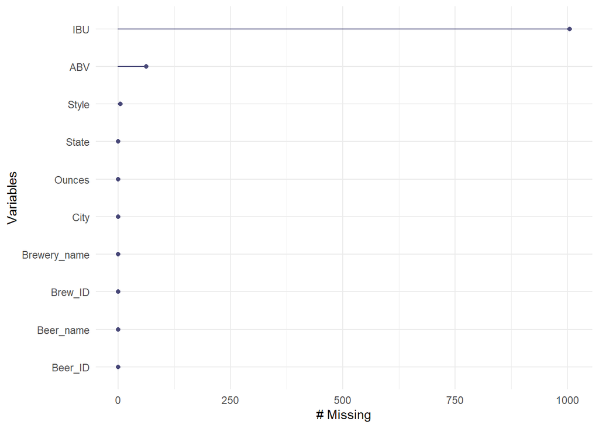

```r
gg_miss_var(all_df)
```

```r
# Remove missing data for beer & rename the Name and Brewery_id Columns
clean_df <- all_df %>% filter(!is.na(ABV) & !is.na(IBU) & !is.na(Style))
dim(clean_df)
```

```
## [1] 1403   10
```

## 4. Compute the median alcohol content and international bitterness unit for each state. Plot a bar chart to compare.

- Maine has the highest median ABV and IBU of all the states. Arkansas and Utah have the lowest median ABV, while Wisconsin has the lowest median IBU.

```r
# Dataframe with median values for ABV and IBU
(med_abv_ibu <- clean_df %>%
  group_by(State) %>%
  summarize(med_abv = median(ABV), med_ibu = median(IBU), count = n()))
```

```
## # A tibble: 50 x 4
##    State med_abv med_ibu count
##    <fct>   <dbl>   <dbl> <int>
##  1 AK      0.057    46      17
##  2 AL      0.06     43       9
##  3 AR      0.04     39       1
##  4 AZ      0.055    20      23
##  5 CA      0.058    42     135
##  6 CO      0.065    40     146
##  7 CT      0.061    29       6
##  8 DC      0.059    47.5     4
##  9 DE      0.055    52       1
## 10 FL      0.062    55      37
## # ... with 40 more rows
```

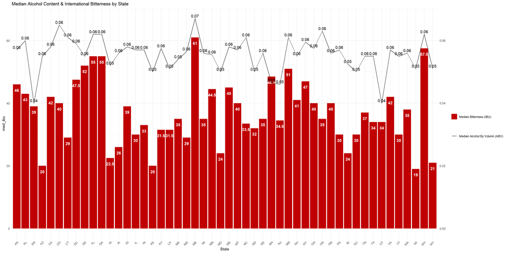

```r
# Plot the median ABV & IBU
p2 <- ggplot(med_abv_ibu, aes(x = State)) +
  geom_col(aes( y = med_ibu, fill="redfill")) +
  geom_text(aes(y = med_ibu, label = med_ibu), fontface = "bold", vjust = 2.4, color = "white", size = 4) +
  geom_line(aes(y = med_abv * 1000, group = 1, color = 'blackline')) +
  geom_text(aes(y = med_abv * 1000, label = round(med_abv, 2)), vjust = -.4, color = "black", size = 4) +
  scale_y_continuous(sec.axis = sec_axis(trans = ~ . / 1000)) +
  scale_fill_manual('', labels = 'Median Bitterness (IBU)', values = "#C00000") +
  scale_color_manual('', labels = 'Median Alcohol By Volumn (ABV)', values = 'black') +
  ggtitle("Median Alcohol Content & International Bitterness by State") +
  theme_minimal()

p2 + rotate_x_text(45)
```

## 5. Which state has the maxiumum alcoholic (ABV) beer? Which state has the most bitter (IBU) beer?

- Kentucky has the highest ABV beer, which is called ‘London Balling’, made by Against the Grain Brewery, located in Louisville city.
- Oregon has the highest IBU beer, which is called ‘Bitter Bitch Imperial IPA’, made by Astoria Brewing Company, located in Astoria city.

```r
# Dataframe with maximum values for ABV and IBU
max_abv_ibu <- clean_df %>% group_by(State) %>% summarize(max_abv = max(ABV), max_ibu = max(IBU), count = n())

#List row with max ABV
view(clean_df[which.max(clean_df$ABV),])

#List row with max IBU
view(clean_df[which.max(clean_df$IBU),])
```

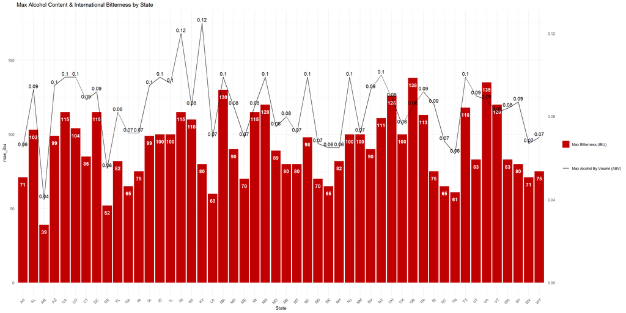

```r
# Plot max values for ABV and IBU
p3 <- ggplot(max_abv_ibu, aes(x = State)) +
  geom_col(aes( y = max_ibu, fill="redfill")) +
  geom_text(aes(y = max_ibu, label = max_ibu), fontface = "bold", vjust = 2.4, color = "white", size = 4) +
  geom_line(aes(y = max_abv * 1400, group = 1, color = 'blackline')) +
  geom_text(aes(y = max_abv * 1400, label = round(max_abv, 2)), vjust = -.4, color = "black", size = 4) +
  scale_y_continuous(sec.axis = sec_axis(trans = ~ . / 1400)) +
  scale_fill_manual('', labels = 'Max Bitterness (IBU)', values = "#C00000") +
  scale_color_manual('', labels = 'Max Alcohol By Volumn (ABV)', values = 'black') +
  ggtitle("Max Alcohol Content & International Bitterness by State") +
  theme_minimal()

p3 + rotate_x_text(45)
```

## 6. Comment on the summary statistics and distribution of the ABV variable.

- The distribution of ABV variable is slightly right-skewed.

```r
#Summary of key statistics of ABV
summary(clean_df$ABV)
```

```
##    Min. 1st Qu.  Median    Mean 3rd Qu.    Max.
## 0.02700 0.05000 0.05700 0.05992 0.06800 0.12500
```

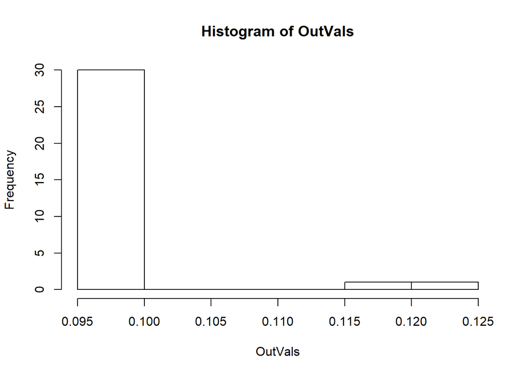

```r
#Outliers
OutVals = boxplot(clean_df$ABV, plot=FALSE)$out
hist(OutVals)
```

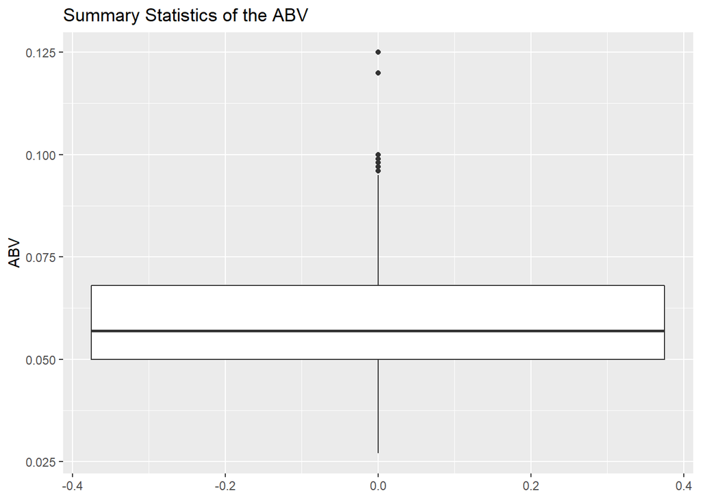

```r
# Plot boxplot
clean_df %>%
  ggplot(aes(y = ABV)) +
  geom_boxplot() +
  ggtitle("Summary Statistics of the ABV") + ylab("ABV")
```

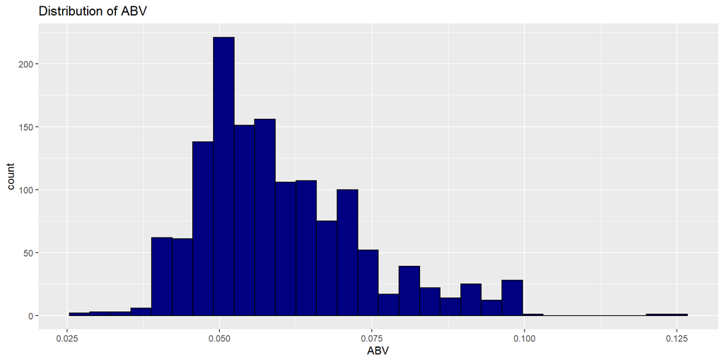

```r
# Plot histogram of hte ABV distribution
clean_df %>%
  ggplot(aes(x = ABV)) +
  geom_histogram(colour="black",fill="navy") +
  ggtitle("Distribution of ABV") + xlab("ABV")
```

```r
# t-test
t.test(clean_df$ABV, conf.level = .95)
```

```
##
##  One Sample t-test
##
## data:  clean_df$ABV
## t = 165.21, df = 1402, p-value < 2.2e-16
## alternative hypothesis: true mean is not equal to 0
## 95 percent confidence interval:
##  0.05920729 0.06063020
## sample estimates:
##  mean of x
## 0.05991875
```

## 7. Is there an apparant relationship between the bitterness of the beer and its alcoholic content? Draw a scatter plot. Make your best judgment of a relationship and EXPLAIN your answer.

- Higher ABV values are associated with higher IBUs and vice versa. With p-value < 2.2e-16, there is sufficient evidence at alpha = .05 level of significance to suggest that the data is linearly correlated. Correlation estimate = 0.67 suggests that the relationship between IBU and ABV is positive and strong.

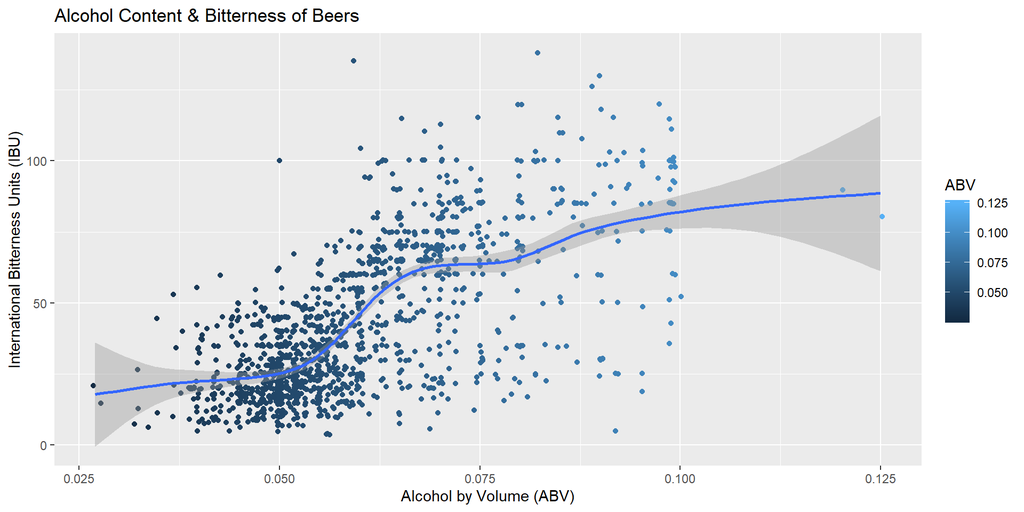

```r
# Plot ABV and IBU
ggplot(data = clean_df) +
  geom_point(mapping = aes(x = ABV, y = IBU, color=ABV), position ="jitter") +
  ggtitle("Alcohol Content & Bitterness of Beers") + xlab("Alcohol by Volume (ABV)") + ylab("International Bitterness Units (IBU)") +
  geom_smooth(mapping = aes(x = ABV, y = IBU))
```

```r
#correlation
cor.test(clean_df$ABV,clean_df$IBU)
```

```
##
##  Pearson's product-moment correlation
##
## data:  clean_df$ABV and clean_df$IBU
## t = 33.848, df = 1401, p-value < 2.2e-16
## alternative hypothesis: true correlation is not equal to 0
## 95 percent confidence interval:
##  0.6408842 0.6985369
## sample estimates:
##       cor
## 0.6707224
```

## 8. Investigate the difference in IBU and ABV between IPAs and other Ales

- IPAs have higher average ABV and IBU than other ales.

```r
# Create a dataframe with only IPAs & Ales
ipa_ale_df <- clean_df %>% filter(str_detect(Style, 'IPA') |str_detect(Style, 'Ale'))

# Add a column for "IPA" or "Ale"
ipa_ale_df$beer_type = ifelse(grepl("IPA", ipa_ale_df$Style), "IPA", "Ale")

# two sample t-test compare ABV/IBU between IPA and Ale
t.test(ipa_ale_df$ABV[ipa_ale_df$beer_type=="IPA"],ipa_ale_df$ABV[ipa_ale_df$beer_type=="Ale"],conf.level = .95)
```

```
##
##  Welch Two Sample t-test
##
## data:  ipa_ale_df$ABV[ipa_ale_df$beer_type == "IPA"] and ipa_ale_df$ABV[ipa_ale_df$beer_type == "Ale"]
## t = 16.23, df = 794.65, p-value < 2.2e-16
## alternative hypothesis: true difference in means is not equal to 0
## 95 percent confidence interval:
##  0.01106438 0.01410901
## sample estimates:
##  mean of x  mean of y
## 0.06914286 0.05655616
```

```r
t.test(ipa_ale_df$IBU[ipa_ale_df$beer_type=="IPA"],ipa_ale_df$IBU[ipa_ale_df$beer_type=="Ale"],conf.level = .95)
```

```
##
##  Welch Two Sample t-test
##
## data:  ipa_ale_df$IBU[ipa_ale_df$beer_type == "IPA"] and ipa_ale_df$IBU[ipa_ale_df$beer_type == "Ale"]
## t = 30.118, df = 797.55, p-value < 2.2e-16
## alternative hypothesis: true difference in means is not equal to 0
## 95 percent confidence interval:
##  35.16402 40.06727
## sample estimates:
## mean of x mean of y
##  71.94898  34.33333
```

```r
# Split data into train and test data
# Train/Test with 70/30
splitPerc = .7
set.seed(4)

trainIndices = sample(1:dim(ipa_ale_df)[1],round(splitPerc * dim(ipa_ale_df)[1]))
train = ipa_ale_df[trainIndices,]
test = ipa_ale_df[-trainIndices,]

dim(train)
```

```
## [1] 661  11
```

```r
head(train)
```

```
##     Brew_ID           Beer_name Beer_ID   ABV IBU
## 504     220  Bozone HopZone IPA    1289 0.070  80
## 587     273        Heady Topper    1111 0.080 120
## 819     420  Sanitas Saison Ale    1392 0.058  20
## 771     376       Big Swell IPA      31 0.062  65
## 71       28             Ironman    2218 0.090  50
## 684     336 Iron Horse Pale Ale    1722 0.050  32
##                              Style Ounces              Brewery_name      City
## 504                   American IPA     12   Bozeman Brewing Company   Bozeman
## 587 American Double / Imperial IPA     16             The Alchemist Waterbury
## 819         Saison / Farmhouse Ale     12   Sanitas Brewing Company   Boulder
## 771                   American IPA     12      Maui Brewing Company   Lahaina
## 71              English Strong Ale     16 450 North Brewing Company  Columbus
## 684        American Pale Ale (APA)     12     Fargo Brewing Company     Fargo
##     State beer_type
## 504    MT       IPA
## 587    VT       IPA
## 819    CO       Ale
## 771    HI       IPA
## 71     IN       Ale
## 684    ND       Ale
```

```r
dim(test)
```

```
## [1] 283  11
```

```r
head(test)
```

```
##    Brew_ID    Beer_name Beer_ID   ABV IBU                    Style Ounces
## 1        1 Get Together    2692 0.045  50             American IPA     16
## 5        2       A Beer    2683 0.042  42  American Pale Ale (APA)     16
## 7        2     Sho'nuff    2680 0.040  13         Belgian Pale Ale     16
## 17       5         Park    2661 0.047  19  American Pale Wheat Ale     12
## 18       5    Westfalia    2660 0.056  16 American Amber / Red Ale     12
## 19       5     Villager    2658 0.063  42             American IPA     12
##                 Brewery_name          City State beer_type
## 1          NorthGate Brewing   Minneapolis    MN       IPA
## 5  Against the Grain Brewery    Louisville    KY       Ale
## 7  Against the Grain Brewery    Louisville    KY       Ale
## 17   Fort Point Beer Company San Francisco    CA       Ale
## 18   Fort Point Beer Company San Francisco    CA       Ale
## 19   Fort Point Beer Company San Francisco    CA       IPA
```

```r
# Run the KNN model on the train and test data with k = 5
classifications = knn(train[,c("ABV","IBU")],test[,c("ABV","IBU")],train$beer_type, prob = TRUE, k = 5)

# Create a confusion matrix of the results with k = 5
table(classifications,test$beer_type)
```

```
##
## classifications Ale IPA
##             Ale 158  20
##             IPA  22  83
```

```r
CM_KNN_IPA = confusionMatrix(table(classifications,test$beer_type))
CM_KNN_IPA
```

```
## Confusion Matrix and Statistics
##
##
## classifications Ale IPA
##             Ale 158  20
##             IPA  22  83
##
##                Accuracy : 0.8516
##                  95% CI : (0.8047, 0.8909)
##     No Information Rate : 0.636
##     P-Value [Acc > NIR] : 6.242e-16
##
##                   Kappa : 0.6808
##
##  Mcnemar's Test P-Value : 0.8774
##
##             Sensitivity : 0.8778
##             Specificity : 0.8058
##          Pos Pred Value : 0.8876
##          Neg Pred Value : 0.7905
##              Prevalence : 0.6360
##          Detection Rate : 0.5583
##    Detection Prevalence : 0.6290
##       Balanced Accuracy : 0.8418
##
##        'Positive' Class : Ale
##
```

```r
# Predict what Budweiser would be classified as
bud_test = data.frame(ABV = .05, IBU = 12)

classify_bud = knn(train[,c("ABV","IBU")], bud_test, train$beer_type, prob = TRUE, k = 5)
classify_bud
```

```
## [1] Ale
## attr(,"prob")
## [1] 1
## Levels: Ale IPA
```

```r
attr(classify_bud,"prob")
```

```
## [1] 1
```

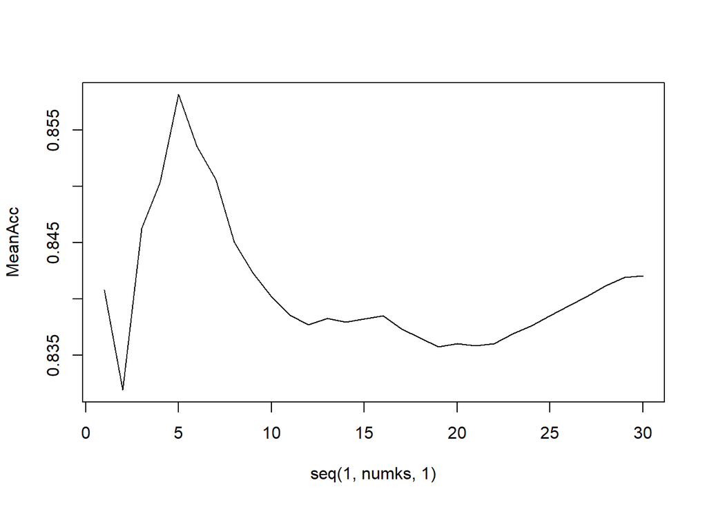

```r
#IPA vs Ale
# Loop for many k and the average of many training / test partition
# to pick the best k for the model

iterations = 200
numks = 30

masterAcc = matrix(nrow = iterations, ncol = numks)

for(j in 1:iterations)
{
accs = data.frame(accuracy = numeric(30), k = numeric(30))
trainIndices = sample(1:dim(ipa_ale_df)[1],round(splitPerc * dim(ipa_ale_df)[1]))
train = ipa_ale_df[trainIndices,]
test = ipa_ale_df[-trainIndices,]
for(i in 1:numks)
{
   classifications = knn(train[,c("ABV","IBU")],test[,c("ABV","IBU")],train$beer_type, prob = TRUE, k = i)
  table(test$beer_type,classifications)
  CM = confusionMatrix(table(test$beer_type,classifications))
  masterAcc[j,i] = CM$overall[1]
}

}

MeanAcc = colMeans(masterAcc)

plot(seq(1,numks,1),MeanAcc, type = "l")
```

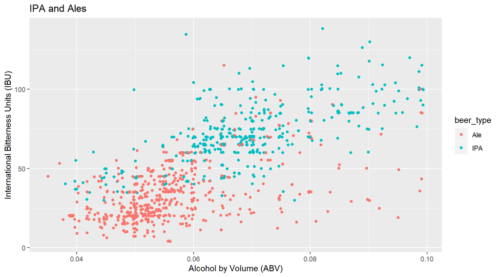

```r
# Plot scatter plot for ABV and IBU of “Ales” and “IPAs”
ggplot(data = ipa_ale_df) +
  geom_point(mapping = aes(x = ABV, y = IBU, color=beer_type), position ="jitter") +
  ggtitle("IPA and Ales") + xlab("Alcohol by Volume (ABV)") + ylab("International Bitterness Units (IBU)")
```

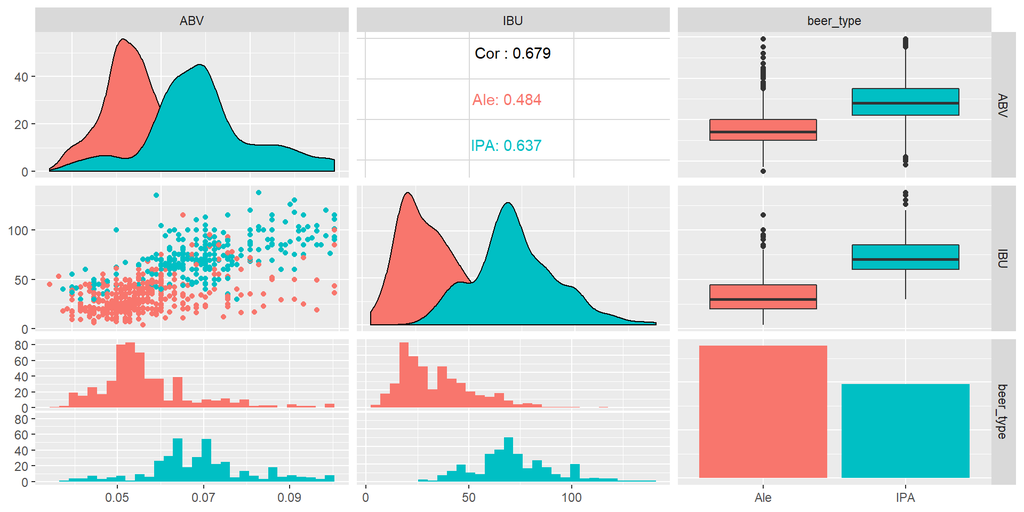

```r
ipa_ale_df %>%
select(ABV, IBU, beer_type) %>%
ggpairs(mapping = aes(color = beer_type))
```

- Here’s a visual result of the kNN results looking at 5 nearest neighbors. The decision boundary line indicates where a beer might get classified as either an IPA or an Ale.

```r
# Boundary plot from Michael Hahsler:  https://michael.hahsler.net/SMU/EMIS7332/R/viz_classifier.html
decision_plot <- function(model, data, class = NULL, predict_type = "class",
  resolution = 5, showgrid = TRUE, ...) {

  if(!is.null(class)) cl <- data[,class] else cl <- 1
  data <- data[,1:2]
  k <- length(unique(cl))

  plot(data, col = as.integer(cl)+1L, pch = as.integer(cl)+1L, ...)

  # make grid
  r <- sapply(data, range, na.rm = TRUE)
  xs <- seq(r[1,1], r[2,1], length.out = resolution)
  ys <- seq(r[1,2], r[2,2], length.out = resolution)
  g <- cbind(rep(xs, each=resolution), rep(ys, time = resolution))
  colnames(g) <- colnames(r)
  g <- as.data.frame(g)

  ### guess how to get class labels from predict
  ### (unfortunately not very consistent between models)
  p <- predict(model, g, type = predict_type)
  if(is.list(p)) p <- p$class
  p <- as.factor(p)

  if(showgrid) points(g, col = as.integer(p)+1L, pch = ".")

  z <- matrix(as.integer(p), nrow = resolution, byrow = TRUE)
  contour(xs, ys, z, add = TRUE, drawlabels = FALSE,
    lwd = 2, levels = (1:(k-1))+.5)

  invisible(z)
}

x_test <- ipa_ale_df[,c(4:5,11)]
x_test$beer_type <- as.factor(x_test$beer_type)
model <- knn3(beer_type ~ ., data=x_test, k = 5)
```

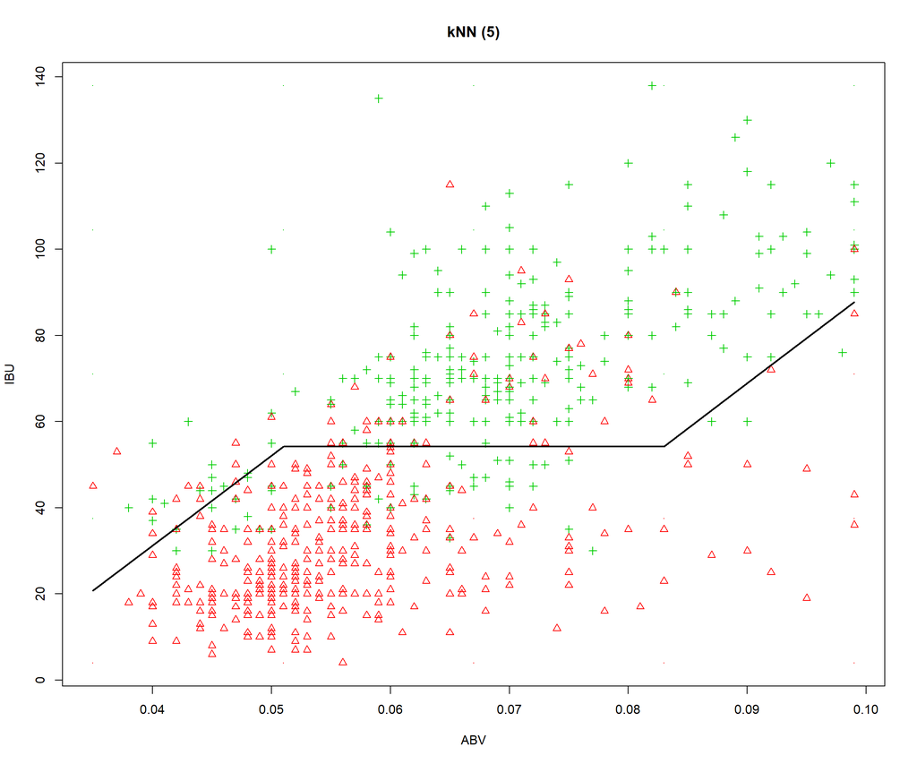

```r
# Boundary plot
decision_plot(model, x_test, class = "beer_type", main = "kNN (5)")
```

## 9a. What states are closest to the Bud ABV/IBU profile?

```r
# Run the KNN model on the train and test data and add the state parameter (Use all data to train/test)
classify_w_state = knn(train[, 4:5],test[, 4:5],train$State, prob = TRUE, k = 5)
classify_bud_st = knn(clean_df[, 4:5], bud_test, clean_df$State, prob = TRUE, k = 3)
CM_KNN_State = confusionMatrix(table(classify_w_state,test$State))
CM_KNN_State
```

[output not shown]

[output cut: 219 more lines]

```
## Pos Pred Value         0.00000       NaN  0.166667  0.200000        NA
## Neg Pred Value         0.97482  0.992933  0.960289  0.974820        NA
## Prevalence             0.02473  0.007067  0.042403  0.028269         0
## Detection Rate         0.00000  0.000000  0.003534  0.003534         0
## Detection Prevalence   0.01767  0.000000  0.021201  0.017668         0
## Balanced Accuracy      0.49094  0.500000  0.532442  0.555227        NA
##                      Class: WY
## Sensitivity           0.000000
## Specificity           0.992857
## Pos Pred Value        0.000000
## Neg Pred Value        0.989324
## Prevalence            0.010601
## Detection Rate        0.000000
## Detection Prevalence  0.007067
## Balanced Accuracy     0.496429
```

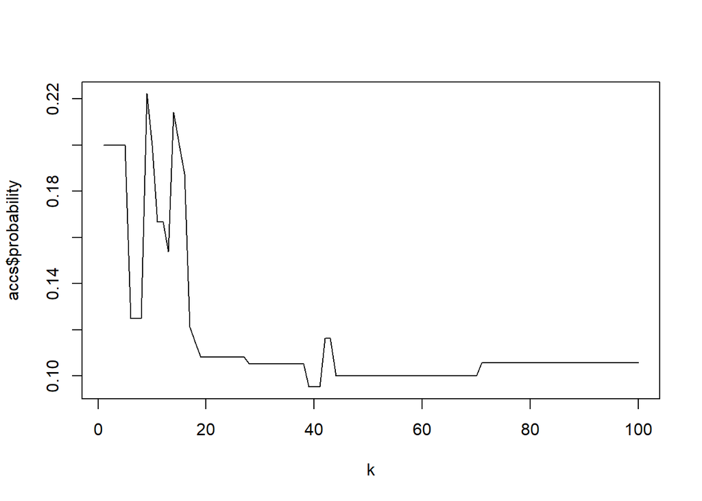

```r
#Run KNN model for 100 different k to find k with highest probabilities
bud_test = data.frame(ABV = .05, IBU = 12)
accs = data.frame(probability = numeric(100), k = numeric(100))

for(i in 1:100)
{
  classifications = knn(clean_df[, 4:5], bud_test, clean_df$State, prob = TRUE, k = i)

  accs$probability[i] = attr(classifications,"prob")[1]
  accs$k[i] = i
}

plot(accs$k,accs$probability, type = "l", xlab = "k")
```

```r
accs %>% arrange(desc(probability))%>% slice(1:10)
```

```
##    probability  k
## 1    0.2222222  9
## 2    0.2142857 14
## 3    0.2000000  1
## 4    0.2000000  2
## 5    0.2000000  3
## 6    0.2000000  4
## 7    0.2000000  5
## 8    0.2000000 10
## 9    0.2000000 15
## 10   0.1875000 16
```

```r
#Find the states for k= 9,14

knn(clean_df[, 4:5], bud_test, clean_df$State, prob = TRUE, k = 9)
```

```
## [1] ID
## attr(,"prob")
## [1] 0.2222222
## 51 Levels: AK AL AR AZ CA CO CT DC DE FL GA HI IA ID IL IN KS KY LA MA ... WY
```

```r
knn(clean_df[, 4:5], bud_test, clean_df$State, prob = TRUE, k = 14)
```

```
## [1] MI
## attr(,"prob")
## [1] 0.2142857
## 51 Levels: AK AL AR AZ CA CO CT DC DE FL GA HI IA ID IL IN KS KY LA MA ... WY
```

[figure not shown]

```r
#Plot
clean_df%>% filter(State=="ID" | State=="MI") %>% select(ABV,IBU,State)%>% ggplot(aes(x= ABV, y=IBU, color =State))+ geom_point() +ggtitle("Indiana and Michigan ABV/IBU")
```

```r
med_abv_ibu%>% filter(State=="ID" | State=="MI")
```

```
## # A tibble: 2 x 4
##   State med_abv med_ibu count
##   <fct>   <dbl>   <dbl> <int>
## 1 ID      0.058      39    17
## 2 MI      0.056      35    38
```

## 9b. What states have a low number of breweries for the population?

New Jersey, Tennessee, and West Virginia have a low number of craft breweries for the population of those states.

```r
# Find out what states have a low # of breweries compared to the state population using census data
# census_api_key("")

# Estimated median income
us_inc <- get_acs(geography = "state", variables = "B19013_001")
us_inc <-  subset(us_inc, select = c(NAME, estimate))
setnames(us_inc, old=c("NAME","estimate"), new=c("id", "med_income_est"))

# Estimated population
us_pop <- get_acs(geography = "state", variables = "B01003_001")
us_pop <- subset(us_pop, select = c(NAME, estimate))
setnames(us_pop, old=c("NAME","estimate"), new=c("id", "pop_est"))

# Merge population & median income
(census_df <- merge(us_inc, us_pop, by="id"))
```

```
##                      id med_income_est  pop_est
## 1               Alabama          46472  4850771
## 2                Alaska          76114   738565
## 3               Arizona          53510  6809946
## 4              Arkansas          43813  2977944
## 5            California          67169 38982847
## 6              Colorado          65458  5436519
## 7           Connecticut          73781  3594478
## 8              Delaware          63036   943732
## 9  District of Columbia          77649   672391
## 10              Florida          50883 20278447
## 11              Georgia          52977 10201635
## 12               Hawaii          74923  1421658
## 13                Idaho          50985  1657375
## 14             Illinois          61229 12854526
```

[output cut: 38 more lines]

```r
# Change the states to lower case so that you can merge it with the brew_by_state dataframe
census_df$id <- tolower(census_df$id)

# Merge census data with the brew_by_state df
brew_by_state_census <- merge(brew_by_state, census_df, by="id")

# Create a column for brewery ratio
brew_by_state_census$brewery_ratio <- round(brew_by_state_census$pop_est/brew_by_state_census$count)

# Create one dataframe that has brew_by_state, census, and median ABV and IBU
master_df <- merge(brew_by_state_census, med_abv_ibu, by="State")

# Sort
master_df <- master_df[order(-master_df$brewery_ratio),]
master_df_final <- subset(master_df, select = c(State, id, count.x, med_income_est, pop_est, brewery_ratio, med_abv, med_ibu))
top_3 <- top_n(master_df_final, 3, brewery_ratio)

View(top_3)
```

## Other: Median IBU of the dataset

```r
#Summary of key statistics of IBU for the conclusions
summary(clean_df$IBU)
```

```
##    Min. 1st Qu.  Median    Mean 3rd Qu.    Max.
##    4.00   21.00   35.00   42.74   64.00  138.00
```